# Location of UK green SMEs

Sylvia Gottschalk

2023-06-11

## BEIS Logitudinal Small Business Survey 2021

The latest wave of the survey of SMEs by the UK Department for Business Energy and Industrial Strategy has 3 years of data on green small businesses. The data show the location of green SMEs in all the nations of the UK and by postcode. The code to obtain a map of these locations is generated using the maps and ggplot libraries. RColorBrewer adds cool palettes:

```r
library(ggplot2)
library(maps)
library(mapproj)
library(dplyr)
```

## Load the data:

```r
df1<- read.csv("postcodes_lsbs_greenmission_2021.csv", sep=",", header=T)
```

We consider SMEs that answer 1) or 2) in the survey as “major green mission” SMEs. Those that answer 3) or 4) are “minor green mission”. Those that answer 5 are not considered green SMEs.

## Plot 1: Major green SMEs

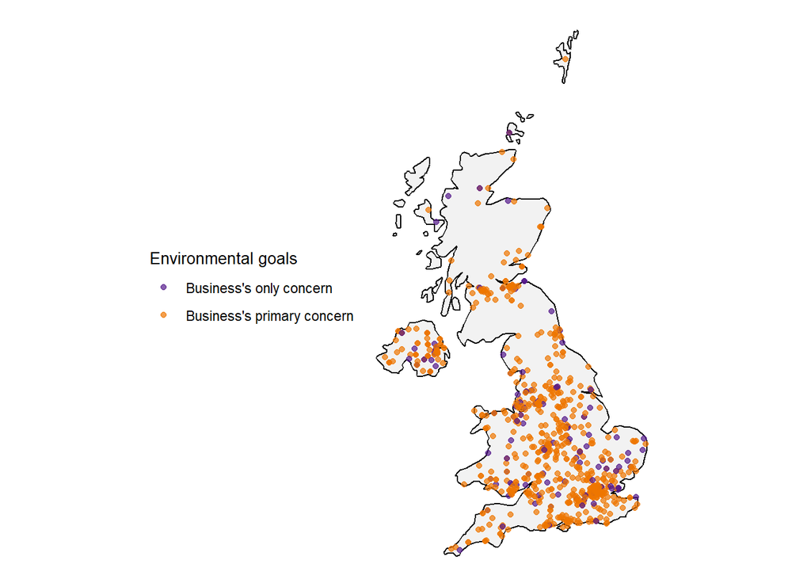

```r
legend_title <- "Environmental goals" #rename the legend title.
UK <- map_data(map = "world", region = "UK") # load "world" map, and then UK
ggplot(data = UK, aes(x = long, y = lat, group = group)) +
  geom_polygon(fill = 'gray95', color = 'black') + theme_void() + #format empty
                                                                   #UK map
  coord_map()+geom_point(data = df1,
                         aes(x = as.numeric(longitude_o), #coordinates of SMEs
                             y = as.numeric(latitude_o), group = D3_2021,
                             colour=factor(D3_2021)),alpha = .7) +
  scale_size_area(max_size = 5) +
  scale_colour_manual(legend_title,labels = c("Business's only concern",
                                              "Business's primary concern"),
                      values = c("purple4", "darkorange2"))+
  theme(title = element_text(size = 10),legend.position="left")
```

Clearly, the vast majority of green SMEs with exclusive environmental objectives are located in England, and in the South East in particular. There is a noticeably high density of SMEs with primary green concerns in Northern Ireland, and the North West of England. The nation with the lowest density of green mission SMEs is Scotland, followed by Wales (northern and central regions). Most of the major green mission SMEs in Scotland are located in the axis Glasgow-Edinburgh.

## Load data for minor green SMEs

```r
df1<- read.csv("postcodes_lsbs_greenlaggards_2021.csv", sep=",", header=T)
```

## Plot 2: minor green mission/no green mission

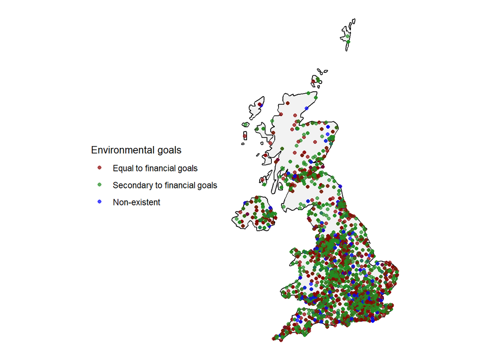

```r
legend_title <- "Environmental goals"
UK <- map_data(map = "world", region = "UK") #load UK map from maps library
ggplot(data = UK, aes(x = long, y = lat, group = group)) +
  geom_polygon(fill = 'gray95', color = 'black') + theme_void()+
  coord_map()+geom_point(data = df1,
                         aes(x = as.numeric(longitude_o),
                             y = as.numeric(latitude_o),
                             group = D3_2021,
                             colour=factor(D3_2021)),alpha = .7) +
  scale_size_area(max_size = 5) +

  scale_colour_manual(legend_title,labels = c("Equal to financial goals",
                                              "Secondary to financial goals",
                                              "Non-existent"),
                      values = c("red4", "forestgreen", "blue"))+
  theme(title = element_text(size = 10),legend.position="left")
```

## References

Sylvia Gottschalk and Robyn Owen (2023) [Demand for external finance by environmentally-motivated SMEs: an exploration of geographical disparities and potential in relation to Net Zero](https://www.enterpriseresearch.ac.uk/publications/demand-for-external-finance-by-environmentally-motivated-smes-an-exploration-of-geographical-disparities-and-potential-in-relation-to-net-zero/), ERC Research Paper 108.